# [OT2020] Lithiase: UML, Schema & Instance

ALDP

28/09/2020

# Definition of relevant fields

Based on our literature review, examples of report result for urolithiasis and expert validation, we determined the list of relevant fields.

We determined items that are mandatory for any radiological report, as the patient identification [name, first name, birthdate, NIR (Numéro d’Inscription au Répertoire)], the protocol characteristic containing information about the imaging device and the exam, the radiologist identification and the conclusion. We detailed the device information with the device model and year of initial commissioning. For exam information we proposed to define the type of exam, it can be CT scan or US, the date and time of the exam, and the indication or clinical context (acute flank pain or lithiasis follow-up).

We determined others items about conditions for performing the urolithiasis imaging. We distinguished enhanced CT scan and NCCT, the use of low dose CT scan or not, exam performed during an acute situation or not, presence of fever, presence of urinary tract diversion. We also informed about the radiation dose expressed in milligray multiplied by centimeter (mGy.cm).

For the results, we established relevant fields such as the description of others organs than urinary tract, the presence of another abnormalitiy, the number of urolithiasis, a detailed description of each urinary tract and of each urinary stone. For the description for each organ (liver, adrenals, pancreas, spleen, ovaries and bladder) we left the possibility to describe the abnormality, the other abnormality concerned pneumoperitoneum or intraperitoneal effusion or abnormal lymph nodes or pelvic phlebolith presence. Specifically in our case, we described the presence of urinary tract abnormality, of urinary tract diversion or renal transplant. Then we informed about the number of lithiasis.

We described the urinary tract by lateralization and diversion and for each of its component elements proposed to measure the diameter or volume, to indicate the presence of hematuria, urinoma, pelviureteric junction and pyelonephritis sign.

Finally, we determined items that should be reported for each stone. It contains the stone lateralization (left, right, upper left in case of duplication, lower left, upper right, lower right), the stone size (defined by the greatest measure of diameter and expressed in millimeters), the stone location (in kidney, proximal ureter or distal ureter depending on above or below the iliac vessels, and bladder) and the stone density (expressed in HU). We specified the consequences of lithiasis, with the item obstruction and its implication.

# UML

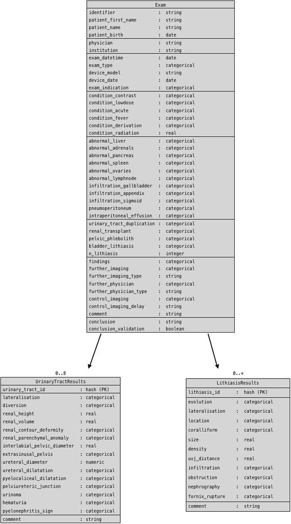

Lithiasis Report:Diagrame UML

# JSON Schema

[Voir les spécifications des schémas JSON](https://json-schema.org)

```json
{
    "$schema": "https://json-schema.org/draft/2019-09/schema#",
    "title": "Lithiasis Report",
    "type": "object",
    "required": ["patient_first_name", "patient_first_name", "patient_birth", "conclusion_validation"],
    "properties": {
        "identifier": {
            "type": "string",
            "description": "Patient unique identifier",
            "minLen": 13,
            "maxLen": 13,
            "pattern": "^[0-9aAbB]{13}$"
        },
        "patient_first_name": {
            "type": "string",
            "description": "Patient's first name"
        },
        "patient_name": {
            "type": "string",
            "description": "Patient's name"
        },
        "patient_birth": {
            "type": "string",
            "description": "Date of birth, format yyyy-mm-dd",
            "format": "date"
        },
        "exam_date_time": {
            "type": "string",
            "description": "Date and time of exam, format yyyy-mm-ddThh:mm:ss+00:00",
            "format": "date-time"
        },
        "exam_type": {
            "type": "string",
            "description": "Exam type",
            "enum": ["CT", "US", "Radiography", "Radiography + US", "NA"]
        },
        "physician": {
            "type": "string",
            "description": "Physician responsible for the interpretation of the imaging results"
        },
        "device_model": {
            "type": "string",
            "description": "Model of imaging device"
        },
        "device_date": {
            "type": "string",
            "description": "Date of device validation",
            "format": "date"
        },
        "exam_indication": {
            "type": "string",
            "description": "Exam indication",
            "enum": ["Abdominal pain", "Renal insufficiency", "Follow up", "Other", "NA"]
        },
        "condition_contrast": {
            "type": "string",
            "description": "Exam using enhanced contrast agent",
            "enum": ["No", "IV", "IV late phase", "Urinary tract injection", "NA"],
            "default": "No"
        },
        "condition_low_dose": {
            "type": "string",
            "description": "Low dose protocol for CT scan",
            "enum": ["Low dose", "Standard dose", "NA"],
            "default": "Low dose"
        },
        "condition_acute": {
            "type": "string",
            "description": "Acute phase / clinical crisis at the time of the exam",
            "enum": ["No", "Yes", "Unknown", "NA"]
        },
        "condition_fever": {
            "type": "string",
            "description": "Patient febrile at the time of the exam",
            "enum": ["No", "Yes", "Unknown", "NA"],
            "default": "NA"
        },
        "condition_derivation": {
            "type": "string",
            "description": "Urinary tract diversion in place at the time of the exam",
            "enum": ["No", "Bladder drainage", "Upper tract drainage", "NA"],
            "default": "No"
        },
        "condition_radiation": {
            "type": "number",
            "description": "Radiation dose related to the exam, mGy.cm"
        },
        "abnormal_liver": {
            "type": "string",
            "description": "Liver anomaly detected",
            "enum": [ "No", "Yes","Unknown", "NA"],
            "default": "NA"
        },
        "abnormal_adrenals": {
            "type": "string",
            "description": "Adrenals anomaly detected",
            "enum": ["No", "Yes", "Unknown", "NA"],
            "default": "NA"
        },
        "abnormal_pancreas": {
            "type": "string",
            "description": "Pancreas anomaly detected",
            "enum": ["No", "Yes", "Unknown", "NA"],
            "default": "NA"
        },
        "abnormal_spleen": {
            "type": "string",
            "description": "Spleen anomaly detected",
            "enum": ["No", "Yes", "Unknown", "NA"],
            "default": "NA"
        },
        "abnormal_ovaries": {
            "type": "string",
            "description": "Ovarian anomaly detected (if female)",
            "enum": ["No", "Yes", "Unknown", "NA"],
            "default": "NA"
        },
        "abnormal_lymphnode": {
            "type": "string",
            "description": "Abnormal lymphnode detected",
            "enum": ["No", "Yes", "Unknown", "NA"],
            "default": "NA"
        },
        "infiltration_gallbladder": {
            "type": "string",
            "description": "Infiltration of the gallbladder",
            "enum": ["No", "Yes", "Unknown", "NA"],
            "default": "NA"
        },
        "infiltration_appendix": {
            "type": "string",
            "description": "Infiltration of the appendix",
            "enum": ["No", "Yes", "Unknown", "NA"],
            "default": "NA"
        },
        "infiltration_sigmoid": {
            "type": "string",
            "description": "Infiltration of the sigmoid",
            "enum": ["No", "Yes", "Unknown", "NA"],
            "default": "NA"
        },
        "pneumoperitoneum": {
            "type": "string",
            "description": "Pneumoperitoneum detected",
            "enum": ["No", "Yes", "Unknown", "NA"],
            "default": "NA"
        },
        "intraperitoneal_effusion": {
            "type": "string",
            "description": "Intraperitoneal effusion detected",
            "enum": ["No", "Yes", "Unknown", "NA"],
            "default": "NA"
        },
        "urinary_tract_duplication": {
            "type": "string",
            "description": "Duplication of urinary tract resulting in an 'additionnal' urinary tract to describe",
            "enum": ["No", "Right", "Left", "Unknown", "NA"],
            "default": "No"
        },
        "renal_transplant": {
            "type": "string",
            "description": "Presence of a renal transplant resulting in an 'additionnal' urinary tract to describe",
            "enum": ["No", "Right", "Left", "Unknown", "NA"],
            "default": "No"
        },
        "bladder_lithiasis":{
            "type": "string",
            "description": "Presence of urolithiasis in the bladder",
            "enum": ["No", "Yes", "NA"],
            "default": "No"
        },
        "pelvic_phlebolith": {
            "type": "string",
            "description": "Presence of pelvic phlebolith(s)",
            "enum": ["No", "Yes", "NA"],
            "default": "No"
        },
        "lithiasis_n": {
            "type": "integer",
            "description": "Number of lithiasis detected on the exam",
            "minimum": 0,
            "maximum": 100
        },
        "lithiasis_results": {
            "type": "object",
            "properties": {
                "lithiasis_id": {
                    "type": "string",
                    "description": "Generated hash id for each successively described lithiasis",
                },
                "evolution": {
                    "type": "string",
                    "description": "Evolution of the lithiasis as compared to previous imaging exam",
                    "enum": ["New", "Stable", "Modified", "NA"],
                    "default": "New"
                },
                "lateralisation": {
                    "type": "string",
                    "description": "Lateralisation of the uro lithiasis to be described",
                    "enum": ["Left", "Right", "Left upper pole", "Left lower pole", "Right upper pole", "Right lower pole", "Left renal transplant", "Right renal transplant", "NA"]
                },
                "location": {
                    "type": "string",
                    "description": "Location of the uro lithiasis to be described in the previously defined urinary tract",
                    "enum": ["Renal pelvis", "Renal major calyx", "Renal minor calyx", "Pelvi-ureteric junction", "Proximal ureter", "Distal ureter", "Vesico-ureteric junction", "Bladder"]
                },
                "corraliform": {
                    "type": "string",
                    "description": "Corraliform aspect of the urolithiasis",
                    "enum": ["No", "Yes", "NA"],
                    "default": "No"
                },
                "size": {
                    "type": "number",
                    "description": "Lithiasis maximal diameter (mm)",
                    "exclusiveMinimum": 0,
                    "maximum": 200
                },
                "density": {
                    "type": "integer",
                    "description": "Lithiasis density (Hounsfield Units)",
                    "minimum": -1000,
                    "maximum": 3000
                },
                "uvj_distance": {
                    "type": "number",
                    "description": "Distance between the lithiasis and the uretero-vesical junction (cm)",
                    "minimum": 0
                },
                "infiltration": {
                    "type": "string",
                    "description": "Tissue infiltration, caused by the urolithiasis",
                    "enum": ["No", "Yes", "Unknown", "NA"],
                    "default": "No"
                },
                "obstruction": {
                    "type": "string",
                    "description": "Urinary tract obstruction sign, caused by the urolithiasis",
                    "enum": ["No", "Visible", "Minor calyces dilatation", "Major calyces dilatation", "Pelvic dilatation", "NA"],
                    "default": "No"
                },
                "nephrography": {
                    "type": "string",
                    "description": "Perturbation of the renal perfusion, caused by the urolithiasis (if enhanced contrast CT)",
                    "enum": ["Normal", "Retarded", "Non measurable", "NA"],
                    "default": "Non measurable"
                },
                "fornix_rupture": {
                    "type": "string",
                    "description": "Presence of a fornix rupture, caused by the urolithiasis",
                    "enum": ["No", "Yes", "Unknown", "NA"],
                },
                "comment": {
                    "type": "string",
                    "description": "Free text for manually added to the uro lithiasis description"
                }
            }
        },
        "urinary_tract_results": {
            "type": "object",
            "description": "Successive description of urinary tracts results, taking account of the (rare) possibility of anatomical variations",
            "properties": {
                "urinary_tract_id": {
                    "type": "string",
                    "description": "Generated hash id for each successively described urinary tract"
                },
                "lateralisation": {
                    "type": "string",
                    "description": "Lateralisation of the urinary tract to be described",
                    "enum": ["Left", "Right", "Left upper pole", "Left lower pole", "Right upper pole", "Right lower pole", "Left renal transplant", "Right renal transplant"]
                },
                "diversion": {
                    "type": "string",
                    "description": "Presence of a urinary diversion in the described urinary tract",
                    "enum": ["No", "jj_stent", "ureteral_catheter", "pyelostomy", "NA"],
                    "default": "No"
                },
                "renal_height": {
                    "type": "number",
                    "description": "Measured heigh of the kidney (mm)",
                    "minimum": 0
                },
                "renal_volume": {
                    "type": "number",
                    "description": "Measured volume of the kidney (cm3)",
                    "minimum": 0
                },
                "renal_contour_deformity": {
                    "type": "string",
                    "description": "Presence of a morphological anomaly of the renal contour (if non contrast enhanced CT)",
```

```json
                    "enum": ["No", "Yes", "Unknown", "NA"]
                },
                "renal_parenchymal_anomaly": {
                    "type": "string",
                    "description": "Presence of a parenchymal anomaly of the kidney (if contrast enhanced CT)",
                    "enum": ["No", "Yes", "Unknown", "NA"]
                },
                "interlabial_pelvic_diameter": {
                    "type": "number",
                    "description": "Measured interlabial antero-posterior diameter of the renal pelvis (mm)",
                    "minimum": 0
                },
                "extra_sinusal_pelvis": {
                    "type": "string",
                    "description": "Presence of an extra-sinusal pelvis",
                    "enum": ["No", "Yes", "Unknown", "NA"]
                },
                "ureteral_diameter": {
                    "type": "number",
                    "description": "Maximal measured diameter of the ureter (mm)",
                    "minimum": 0
                },
                "ureteral_dilatation": {
                    "type": "string",
                    "description": "Presence of an abnormal ureteral dilatation",
                    "enum": ["No", "Yes", "Unknown", "NA"],
                    "default": "No"
                },
                "pyelocaliceal_dilatation": {
                    "type": "string",
                    "description": "Presence of an abnormal pyelocaliceal dilatation",
                    "enum": ["No", "Yes", "Unknown", "NA"],
                    "default": "No"
                },
                "pelviureteric_junction": {
                    "type": "string",
                    "description": "Suspicion of pelvi-ureteric junction syndrom",
                    "enum": ["No", "Yes", "Unknown", "NA"],
                    "default": "No"
                },
                "urinoma": {
                    "type": "string",
                    "description": "Presence of a peri-renal urinoma",
                    "enum": ["No", "Yes", "Unknown", "NA"],
                    "default": "No"
                },
                "hematuria": {
                    "type": "string",
                    "description": "Presence of hematuria",
                    "enum": ["No", "Yes", "Unknown", "NA"],
                    "default": "No"
                },
                "pyelonephritis_sign": {
                    "type": "string",
                    "description": "Presence of pyelonephritis sign",
                    "enum": ["No", "Yes", "Unknown", "NA"]
                },
                "comment": {
                    "type": "string",
                    "description": "Free text for manually added to the urinary tract description"
                }
            }
        },
        "findings": {
            "type": "string",
            "description": "Qualification of the findings",
            "enum": ["Normal", "Abnormal compatible with clinical description", "abnormal not explanatory for clinical description", "Unknown", "NA"]
        },
        "further_imaging": {
            "type": "string",
            "description": "Need for further imaging exam",
            "enum": ["No", "Additionnal imaging exam needed", "Urgent additional imaging exam need", "Unknown", "NA"],
            "default": "No"
        },
        "further_imaging_type": {
            "type": "string",
            "description": "Type of further imaging exam advised"
        },
        "further_physician": {
            "type": "string",
            "description": "Need for further physician opinion",
            "enum": ["No", "Further physician opinion advised", "Urgent physician opinion needed", "Unknown", "NA"],
            "default": "No"
        },
        "further_physician_type": {
            "type": "string",
            "description": "Type of further physician opinion exam advised"
        },
        "control_imaging": {
            "type": "string",
            "description": "Need for control imaging exam",
            "enum": ["No", "Control exam needed", "Unknown", "NA"],
            "default": "No"
        },
        "control_imaging_delay": {
            "type": "string",
            "description": "Time to control imaging exam"
        },
        "comment": {
            "type": "string",
            "description": "Free text for manually added results, or comment"
        },
        "conclusion": {
            "type": "string",
            "description": "Text conclusion, automatically generated, and validated by the imaging physician"
        },
        "conclusion_validation": {
            "type": "boolean",
            "description": "The physician must validate the automatically generated conclusion, after manual modification if required",
            "default": false
        }
    }
}
```

# YAML Instance

[Voir les spécifications yaml sur les ‘collections’](https://yaml.org/spec/1.2/spec.html#id2759963)

## Premier modèle d’instance

```yaml
%YAML 1.2
---
Exam:
  schema: medical_imaging_report/ot2020_lithiasis.schema.json
  identifier: id12345678910
  patient_first_name: Marie
  patient_name: Trencart
  patient_birth: 1901-01-01
  exam_date_time: 2020-10-30T14:00:00
  exam_type: CT
  physician: Philippe PUECH
  device_model: MX Twin Flash, Marconi Medical Systems, Cleveland, Ohio
  device_date: 2020-01-01
  exam_indication: Abdominal pain
  condition_contrast: "No"
  condition_low_dose: Low dose
  condition_acute: "Yes"
  condition_fever: "No"
  condition_derivation: Upper tract drainage
  condition_radiation: 276
  abnormal_liver: "No"
  abnormal_adrenals: "No"
  abnormal_pancreas: "No"
  abnormal_spleen: "No"
  abnormal_ovaries: "No"
  abnormal_lymphnode: "Yes"
  infiltration_gallbladder: "No"
  infiltration_appendix: "No"
  infiltration_sigmoid: "No"
  pneumoperitoneum: "No"
  intraperitoneal_effusion: "No"
  urinary_tract_duplication: Right
  renal_transplant: "No"
  bladder_lithiasis: "Yes"
  pelvic_phlebolith: "Yes"
  lithiasis_n: 3
  lithiasis_results:
    - lithiasis_id: l1
      evolution: New
      lateralisation: Left
      location: Renal pelvis
      coralliform: "No"
      size: 11
      density: 600
      uvj_distance: NA
      infiltration: "Yes"
      obstruction: "No"
      nephrography: Normal
      fornix_rupture: "No"
      comment: NA
    - lithiasis_id: l2
      evolution: Stable
      lateralisation: Right upper pole
      location: Pelvi-ureteric junction
      corraliform: "No"
      size: 8
      density: 700
      uvj_distance: NA
      infiltration: "No"
      obstruction: Minor calyces dilatation
      nephrography: Retarded
      fornix_rupture: "No"
      comment: NA
    - lithiasis_id: l3
      evolution: Stable
      lateralisation: NA
      location: Bladder
      corraliform: "No"
      size: 8
      density: 700
      uvj_distance: NA
      infiltration: "No"
      obstruction: "No"
      nephrography: Normal
      fornix_rupture: "No"
      comment: NA
  urinary_tract_results:
    - urinary_tract_id: ut1
      lateralisation: Left
      diversion: "No"
      renal_height: 108
      renal_volume: NA
      renal_contour_deformity: "No"
      renal_parenchymal_anomaly: Unknown
      interlabial_pelvic_diameter:  16
      extra_sinusal_pelvis: "No"
      ureteral_diameter: 0
      ureteral_dilatation: "No"
      pyelocaliceal_dilatation: "No"
      pelviureteric_junction: "No"
      urinoma: "No"
      hematuria: "Yes"
      pyelonephritis_sign: "No"
      comment: Hypodense lesion corresponding to a renal cyst
    - urinary_tract_id: ut2
      lateralisation: Right upper pole
      diversion: "No"
      renal_height: 70
      renal_volume: NA
      renal_contour_deformity: "No"
      renal_parenchymal_anomaly: Unknown
      interlabial_pelvic_diameter: 9
      extra_sinusal_pelvis: "No"
      ureteral_diameter: 2
      ureteral_dilatation: "No"
      pyelocaliceal_dilatation: "Yes"
      pelviureteric_junction: "No"
      urinoma: "No"
      hematuria: "No"
      pyelonephritis_sign: "No"
      comment: NA
    - urinary_tract_id: ut3
      lateralisation: Right lower pole
      diversion: pyelostomy
      renal_height: 40
      renal_volume: NA
      renal_contour_deformity: "No"
      renal_parenchymal_anomaly: Unknown
      interlabial_pelvic_diameter: 4
      extra_sinusal_pelvis: "No"
      ureteral_diameter: 0
      ureteral_dilatation: "No"
      pyelocaliceal_dilatation: "No"
      pelviureteric_junction: Unknown
      urinoma: "No"
      hematuria: "No"
      pyelonephritis_sign: "No"
      comment: NA
  findings: Abnormal compatible with clinical description
  further_imaging: "No"
  further_imaging_type: NA
  further_physician: Further physician opinion advised
  further_physician_type: Urologist
  control_imaging: Control exam needed
  control_imaging_delay: 6 weeks
  comment: NA
  conclusion: NA
  conclusion_validation: true
```

**A noter: Ce modèle comporte 3 904 caractères**

### Import du fichier .yaml

On importe le fichier .yaml à l’aide de la fonction `read_yaml()` issue du package `yaml`

A noter, la fonction `read_yaml()` ne gère pas la métadonnée des deux premières lignes:

```yaml
%YAML 1.2
---
```

```r
report_lithiase <- read_yaml(file='ot2020_lithiase.instance.yaml', fileEncoding = "UTF-8")
```

La fonction `read_yaml()` va creer un objet de type liste contenant -entre autres- des listes

```r
str(report_lithiase)
```

```
## List of 1
##  $ Exam:List of 45
##   ..$ schema                   : chr "medical_imaging_report/ot2020_lithiasis.schema.json"
##   ..$ identifier               : chr "id12345678910"
##   ..$ patient_first_name       : chr "Marie"
##   ..$ patient_name             : chr "Trencart"
##   ..$ patient_birth            : chr "1901-01-01"
##   ..$ exam_date_time           : chr "2020-10-30T14:00:00"
##   ..$ exam_type                : chr "CT"
##   ..$ physician                : chr "Philippe PUECH"
##   ..$ device_model             : chr "MX Twin Flash, Marconi Medical Systems, Cleveland, Ohio"
##   ..$ device_date              : chr "2020-01-01"
##   ..$ exam_indication          : chr "Abdominal pain"
##   ..$ condition_contrast       : chr "No"
##   ..$ condition_low_dose       : chr "Low dose"
##   ..$ condition_acute          : chr "Yes"
##   ..$ condition_fever          : chr "No"
##   ..$ condition_derivation     : chr "Upper tract drainage"
##   ..$ condition_radiation      : int 276
##   ..$ abnormal_liver           : chr "No"
##   ..$ abnormal_adrenals        : chr "No"
##   ..$ abnormal_pancreas        : chr "No"
##   ..$ abnormal_spleen          : chr "No"
##   ..$ abnormal_ovaries         : chr "No"
##   ..$ abnormal_lymphnode       : chr "Yes"
##   ..$ infiltration_gallbladder : chr "No"
##   ..$ infiltration_appendix    : chr "No"
##   ..$ infiltration_sigmoid     : chr "No"
##   ..$ pneumoperitoneum         : chr "No"
##   ..$ intraperitoneal_effusion : chr "No"
##   ..$ urinary_tract_duplication: chr "Right"
##   ..$ renal_transplant         : chr "No"
##   ..$ bladder_lithiasis        : chr "Yes"
##   ..$ pelvic_phlebolith        : chr "Yes"
##   ..$ lithiasis_n              : int 3
##   ..$ lithiasis_results        :List of 3
##   .. ..$ :List of 13
##   .. .. ..$ lithiasis_id  : chr "l1"
##   .. .. ..$ evolution     : chr "New"
##   .. .. ..$ lateralisation: chr "Left"
```

[output cut: 88 more lines]

```
##   .. .. ..$ pelviureteric_junction     : chr "Unknown"
##   .. .. ..$ urinoma                    : chr "No"
##   .. .. ..$ hematuria                  : chr "No"
##   .. .. ..$ pyelonephritis_sign        : chr "No"
##   .. .. ..$ comment                    : chr "NA"
##   ..$ findings                 : chr "Abnormal compatible with clinical description"
##   ..$ further_imaging          : chr "No"
##   ..$ further_imaging_type     : chr "NA"
##   ..$ further_physician        : chr "Further physician opinion advised"
##   ..$ further_physician_type   : chr "Urologist"
##   ..$ control_imaging          : chr "Control exam needed"
##   ..$ control_imaging_delay    : chr "6 weeks"
##   ..$ comment                  : chr "NA"
##   ..$ conclusion               : chr "NA"
##   ..$ conclusion_validation    : logi TRUE
```

### Transformation en dataframe

On peut par la suite tenter de creer un dataframe à partir d’une des listes, par exemple *lithiasis_results*

```r
data.frame(Reduce(rbind, report_lithiase$Exam["lithiasis_results"]))
```

```
##   lithiasis_id evolution lateralisation     location coralliform size density
## 1           l1       New           Left Renal pelvis          No   11     600
##   uvj_distance infiltration obstruction nephrography fornix_rupture comment
## 1           NA          Yes          No       Normal             No      NA
##   lithiasis_id.1 evolution.1 lateralisation.1              location.1
## 1             l2      Stable Right upper pole Pelvi-ureteric junction
##   corraliform size.1 density.1 uvj_distance.1 infiltration.1
## 1          No      8       700             NA             No
##              obstruction.1 nephrography.1 fornix_rupture.1 comment.1
## 1 Minor calyces dilatation       Retarded               No        NA
##   lithiasis_id.2 evolution.2 lateralisation.2 location.2 corraliform.1 size.2
## 1             l3      Stable               NA    Bladder            No      8
##   density.2 uvj_distance.2 infiltration.2 obstruction.2 nephrography.2
## 1       700             NA             No            No         Normal
##   fornix_rupture.2 comment.2
## 1               No        NA
```

Problème:

- On s’attend à obtenir 3 valeurs par variables : 3 lithiases à décrire = 3 valeurs de lithiasis_id, 3 valeurs de lateralisation etc…
- Or on observe -pour chaque variable de la liste- 3 variables successives dans le dataframe, contenant chacune 1 valeur

## Second modèle d’instance: YAML’s “Flow Style”

On utilise une fonctionalité du yaml, qui permet la notation en *Flow style*

[Voir les spécifications yaml sur les ‘collections’](https://yaml.org/spec/1.2/spec.html#id2759963)

```yaml
%YAML 1.2
---
Exam:
  schema: medical_imaging_report/ot2020_lithiasis.schema.json
  identifier: id12345678910
  patient_first_name: Marie
  patient_name: Trencart
  patient_birth: 1901-01-01
  exam_date_time: 2020-10-30T14:00:00
  exam_type: CT
  physician: Philippe PUECH
  device_model: MX Twin Flash
  device_date: 2020-01-01
  exam_indication: Abdominal pain
  condition_contrast: "No"
  condition_low_dose: Low dose
  condition_acute: "Yes"
  condition_fever: "No"
  condition_derivation: Upper tract drainage
  condition_radiation: 276
  abnormal_liver: "No"
  abnormal_adrenals: "No"
  abnormal_pancreas: "No"
  abnormal_spleen: "No"
  abnormal_ovaries: "No"
  abnormal_lymphnode: "Yes"
  infiltration_gallbladder: "No"
  infiltration_appendix: "No"
  infiltration_sigmoid: "No"
  pneumoperitoneum: "No"
  intraperitoneal_effusion: "No"
  urinary_tract_duplication: Right
  renal_transplant: "No"
  bladder_lithiasis: "Yes"
  pelvic_phlebolith: "Yes"
  lithiasis_n: 3
  lithiasis_results:
    lithiasis_id: [l1, l2, l3]
    evolution: [New, Stable, Stable]
    lateralisation: [Left, Right upper pole, NA]
    location: [Renal pelvis, Pelvi-ureteric junction, Bladder]
    coralliform: ["No", "No", "No"]
    size: [11, 8, 8]
    density: [600, 700, 700]
    uvj_distance: [NA, NA, NA]
    infiltration: ["Yes", "No", "No"]
    obstruction: ["No", Minor calyces dilatation, "No"]
    nephrography: [Normal, Retarded, Normal]
    fornix_rupture: ["No", "No", "No"]
    comment: [NA, NA, NA]
  urinary_tract_results:
    urinary_tract_id: [ut1, ut2, ut3]
    lateralisation: [Left, Right upper pole, Right lower pole]
    diversion: ["No", "No", pyelostomy]
    renal_height: [108, 70, 40]
    renal_volume: [NA, NA, NA]
    renal_contour_deformity: ["Yes", "No", "No"]
    renal_parenchymal_anomaly: [Unknown, Unknown, Unknown]
    interlabial_pelvic_diameter:  [16, 9, 4]
    extra_sinusal_pelvis: ["No", "No", "No"]
    ureteral_diameter: [0, 2, 0]
    ureteral_dilatation: ["No", "No", "No"]
    pyelocaliceal_dilatation: ["No", "Yes", "No"]
    pelviureteric_junction: ["No", "No", Unknown]
    urinoma: ["No", "No", "No"]
    hematuria: ["Yes", "No", "No"]
    pyelonephritis_sign: ["No", "No", "No"]
    comment: [Hypodense lesion corresponding to a renal cyst, NA, NA]
  findings: Abnormal compatible with clinical description
  further_imaging: No
  further_imaging_type: null
  further_physician: Further physician opinion advised
  further_physician_type: Urologist
  control_imaging: Control exam needed
  control_imaging_delay: 6 weeks
  comment: NA
  conclusion: NA
  conclusion_validation: true
```

**A noter, ce modèle comporte 2 609 caractères**

### Import du fichier .yaml “condensé”

```r
report_lithiase_condensed <- read_yaml(file='ot2020_lithiase_condensed.instance.yaml', fileEncoding = "UTF-8")
```

On profite du fait que les noms des variables récurrentes qui apparaissaient plusieurs fois (du fait de la cardinalité >1 de lithiasis_results et urinary_tract_results), n’apparaissent ici plus qu’une fois.

```r
str(report_lithiase_condensed)
```

```
## List of 1
##  $ Exam:List of 45
##   ..$ schema                   : chr "medical_imaging_report/ot2020_lithiasis.schema.json"
##   ..$ identifier               : chr "id12345678910"
##   ..$ patient_first_name       : chr "Marie"
##   ..$ patient_name             : chr "Trencart"
##   ..$ patient_birth            : chr "1901-01-01"
##   ..$ exam_date_time           : chr "2020-10-30T14:00:00"
##   ..$ exam_type                : chr "CT"
##   ..$ physician                : chr "Philippe PUECH"
##   ..$ device_model             : chr "MX Twin Flash"
##   ..$ device_date              : chr "2020-01-01"
##   ..$ exam_indication          : chr "Abdominal pain"
##   ..$ condition_contrast       : chr "No"
##   ..$ condition_low_dose       : chr "Low dose"
##   ..$ condition_acute          : chr "Yes"
##   ..$ condition_fever          : chr "No"
##   ..$ condition_derivation     : chr "Upper tract drainage"
##   ..$ condition_radiation      : int 276
##   ..$ abnormal_liver           : chr "No"
##   ..$ abnormal_adrenals        : chr "No"
##   ..$ abnormal_pancreas        : chr "No"
##   ..$ abnormal_spleen          : chr "No"
##   ..$ abnormal_ovaries         : chr "No"
##   ..$ abnormal_lymphnode       : chr "Yes"
##   ..$ infiltration_gallbladder : chr "No"
##   ..$ infiltration_appendix    : chr "No"
##   ..$ infiltration_sigmoid     : chr "No"
##   ..$ pneumoperitoneum         : chr "No"
##   ..$ intraperitoneal_effusion : chr "No"
##   ..$ urinary_tract_duplication: chr "Right"
##   ..$ renal_transplant         : chr "No"
##   ..$ bladder_lithiasis        : chr "Yes"
##   ..$ pelvic_phlebolith        : chr "Yes"
##   ..$ lithiasis_n              : int 3
##   ..$ lithiasis_results        :List of 13
##   .. ..$ lithiasis_id  : chr [1:3] "l1" "l2" "l3"
##   .. ..$ evolution     : chr [1:3] "New" "Stable" "Stable"
##   .. ..$ lateralisation: chr [1:3] "Left" "Right upper pole" "NA"
##   .. ..$ location      : chr [1:3] "Renal pelvis" "Pelvi-ureteric junction" "Bladder"
```

[output cut: 22 more lines]

```
##   .. ..$ pelviureteric_junction     : chr [1:3] "No" "No" "Unknown"
##   .. ..$ urinoma                    : chr [1:3] "No" "No" "No"
##   .. ..$ hematuria                  : chr [1:3] "Yes" "No" "No"
##   .. ..$ pyelonephritis_sign        : chr [1:3] "No" "No" "No"
##   .. ..$ comment                    : chr [1:3] "Hypodense lesion corresponding to a renal cyst" "NA" "NA"
##   ..$ findings                 : chr "Abnormal compatible with clinical description"
##   ..$ further_imaging          : logi FALSE
##   ..$ further_imaging_type     : NULL
##   ..$ further_physician        : chr "Further physician opinion advised"
##   ..$ further_physician_type   : chr "Urologist"
##   ..$ control_imaging          : chr "Control exam needed"
##   ..$ control_imaging_delay    : chr "6 weeks"
##   ..$ comment                  : chr "NA"
##   ..$ conclusion               : chr "NA"
##   ..$ conclusion_validation    : logi TRUE
```

### Transformation en dataframe

On peut par la suite tenter de creer un dataframe à partir d’une des listes, par exemple *lithiasis_results*

```r
data.frame(Reduce(rbind, report_lithiase_condensed$Exam["lithiasis_results"]))
```

```
##   lithiasis_id evolution   lateralisation                location coralliform
## 1           l1       New             Left            Renal pelvis          No
## 2           l2    Stable Right upper pole Pelvi-ureteric junction          No
## 3           l3    Stable               NA                 Bladder          No
##   size density uvj_distance infiltration              obstruction nephrography
## 1   11     600           NA          Yes                       No       Normal
## 2    8     700           NA           No Minor calyces dilatation     Retarded
## 3    8     700           NA           No                       No       Normal
##   fornix_rupture comment
## 1             No      NA
## 2             No      NA
## 3             No      NA
```

```r
knitr::kable(data.frame(Reduce(rbind, report_lithiase_condensed$Exam["lithiasis_results"])), caption= "Lithiases")
```

Lithiases

| lithiasis_id | evolution | lateralisation | location | coralliform | size | density | uvj_distance | infiltration | obstruction | nephrography | fornix_rupture | comment |
| --- | --- | --- | --- | --- | --- | --- | --- | --- | --- | --- | --- | --- |
| l1 | New | Left | Renal pelvis | No | 11 | 600 | NA | Yes | No | Normal | No | NA |
| l2 | Stable | Right upper pole | Pelvi-ureteric junction | No | 8 | 700 | NA | No | Minor calyces dilatation | Retarded | No | NA |
| l3 | Stable | NA | Bladder | No | 8 | 700 | NA | No | No | Normal | No | NA |

# QRCode

Encodage du fichier d’instance YAML dans un QRCode à l’aide de la librairie python [`python-qrcode`](https://github.com/lincolnloop/python-qrcode) appelée avec la ligne de commande suivante

*A noter que l’on fixe le niveau de redondance du code à 7% (“L”)*

```bash
less instance.yaml | qr --error-correction=L > instance.png
```

[figure not shown]

Instance sérialisée en yaml, encodée dans un QRCode

# Template

| Mr/Ms | `{patient_name}` `{patient_first_name}` |
| --- | --- |
| Date of birth | `{patient_birth}` |
| Date of exam | `{exam_date_time}` |
| Exam type | `{exam_type}` |
| Radiologist | `{physician}` |

## Exam

Indication: `{exam_indication}`

Conditions: `{exam_type}`, `{device_model}` `{device_date}`, `{condition_contrast}`, `{condition_low_dose}`, made in `{condition_acute}`, with`{condition_fever}` and with `{condition_derivation}`.  
PDL: `{condition_radiation}`.

## Results:

### General results

`{if abnormal_liver = “No”}`  
No liver abdnormality.  
`{else}`  
The liver presents `{abnormal_liver: comments}`

`{if abnormal_pancreas = “No”}`  
No pancreas abdnormality.  
`{else}`  
The pancreas presents `{abnormal_pancreas: comments}`

(…)

### Urinary tract

`{foreach urinary_tract_results as utr}`

- `{[utr]lateralization}` kidney:
  - Measuring `{renal_height}`cm long and `{renal_volume}`cm3
  - `{if [utr]diversion <>= “No”}`
  - No urinary tract diversion.
  - `{else}`
  - Presence of a urinary tract diversion: `{[utr]diversion}`
  - `{if [utr]pyelocaliceal_dilatation = “No}`”
  - No pyelocaliceal dilatation
  - `{else}`
  - Pyelocaliceal dilatation with a interlabial pelvic diameter of `{interlabial_pelvic_diameter}`mm.

### Lithiasis

`{foreach lithiasis_results as lr}`  
Lithiasis `{[lr]location}` `{[lr]lateralization}` of `{[lr]size}`mm and density of `{[lr]density}` HU,  
`{if [lr]obstruction = “No”}`  
Non obstructive.  
`{else}`  
obstructive

## Conclusion:

`{findings}`

`{if further_imaging <> No}`  
Need for `{further_imaging_type}`

`{if further_physician <> No}`  
Need for `{further_physician_type}` opinion advice

Dr.`{physician}`